======================================================== analysis of loan data sets

# ——观察数据，确定研究问题

### 根据lc数据框，研究以下问题：

借款利率与哪些变量相关，相关性最强的变量是什么

### 通过lp数据框，研究以下问题：

ListingId列查看异常值具体数据

### 根据lcis数据框，研究以下问题：

1.标当前状态为”逾期中“的标有什么特点。哪个特点与逾期标相关性最强。  
2.如果投资收益=已还利息+待还利息，标当前状态为“已还清”的标，则收益率高的标有什么特点。

### 查看lc数据框

lc数据框有328553个观测值，21个变量。

# ——清理数据

## 整理数据框

```
##   ListingId            借款金额         借款期限        借款利率
##  Length:328553      Min.   :   100   Min.   : 1.00   Min.   : 6.5
##  Class :character   1st Qu.:  2033   1st Qu.: 6.00   1st Qu.:20.0
##  Mode  :character   Median :  3397   Median :12.00   Median :20.0
##                     Mean   :  4424   Mean   :10.21   Mean   :20.6
##                     3rd Qu.:  5230   3rd Qu.:12.00   3rd Qu.:22.0
##                     Max.   :500000   Max.   :24.00   Max.   :24.0
##
##   借款成功日期          year            month            day
##  Min.   :2015-01-01   2015: 30121   01     :52927   25     : 13198
##  1st Qu.:2016-05-08   2016:255482   12     :47570   20     : 12965
##  Median :2016-09-11   2017: 42950   11     :39593   12     : 12824
##  Mean   :2016-08-05                 10     :35333   16     : 11972
##  3rd Qu.:2016-12-01                 09     :28756   18     : 11529
##  Max.   :2017-01-30                 08     :28734   19     : 11511
##                                     (Other):95640   (Other):254554
##  初始评级      借款类型      是否首标         年龄       性别
##  F:  1489   APP闪电:112079   否:241090   Min.   :17.00   男:221946
##  E: 17027   电商   :  1069   是: 87463   1st Qu.:24.00   女:106607
##  D:134860   普通   :118103               Median :28.00
##  C:131705   其他   : 97302               Mean   :29.14
##  B: 33188                                3rd Qu.:33.00
##  A: 10284                                Max.   :56.00
##
##    手机认证           户口认证           视频认证
##  Length:328553      Length:328553      Length:328553
##  Class :character   Class :character   Class :character
##  Mode  :character   Mode  :character   Mode  :character
##
##
##
##
##    学历认证           征信认证           淘宝认证
##  Length:328553      Length:328553      Length:328553
##  Class :character   Class :character   Class :character
##  Mode  :character   Mode  :character   Mode  :character
##
##
##
##
```

[output cut: 9 more lines]

```
##  Min.   : 0.0000   Min.   :   100       Min.   :0.0000
##  1st Qu.: 0.0000   1st Qu.:  2045       1st Qu.:0.0000
##  Median : 0.0000   Median :  3292       Median :1.0000
##  Mean   : 0.4233   Mean   :  3833       Mean   :0.8416
##  3rd Qu.: 0.0000   3rd Qu.:  4500       3rd Qu.:1.0000
##  Max.   :60.0000   Max.   :500000       Max.   :6.0000
##                    NA's   :87463
##  历史逾期还款期数占比
##  Min.   :0.00
##  1st Qu.:0.00
##  Median :0.00
##  Mean   :0.04
##  3rd Qu.:0.00
##  Max.   :1.00
##  NA's   :88951
```

通过观察数据摘要：  
- 借款利率多在年化率20%-22%，有个别借款人利率低达6.5%，不知道是什么原因，需要查看具体数据，了解异常值。  
- 借款用户年龄最小17岁，还款能力可能较弱，需要查看具体数据，年龄和逾期还款是否有关。  
- 历史成功借款次数最多达649次。需要查看具体数据，了解异常值。  
- 历史正常还款期数，最多达2507。需要查看具体数据，了解异常值。

## 查看异常值

通过lp数据框，查看异常值6.5的原因

```
##       ListingId 期数 还款状态 应还本金 应还利息 剩余本金 剩余利息
## 41598   3097341    1        1    5e+05  2708.33        0        0
##         到期日期   还款日期 recorddate
## 41598 2015-08-06 2015-08-06 2017-02-22
```

经查看lp数据框,年化率6.5是不合理值，删除此行数据。

通过lp数据框，查看异常值649的原因

经查看lp数据框，只查到一次借款数据，由于lp数据框是2015年1月1日到2017年1月30日数据，不能查明total_success_loan_times是649的数据情况。

```
##       ListingId 期数 还款状态 应还本金 应还利息 剩余本金 剩余利息
## 22739   2402951    1        1  1939.52   160.42        0        0
## 22740   2402951    2        1  1965.38   134.56        0        0
## 22741   2402951    3        1  1991.58   108.36        0        0
## 22742   2402951    4        1  2018.14    81.80        0        0
## 22743   2402951    5        1  2045.05    54.89        0        0
## 22744   2402951    6        1  2072.33    27.61        0        0
##         到期日期   还款日期 recorddate
## 22739 2015-06-12 2015-06-07 2017-02-22
## 22740 2015-07-12 2015-06-30 2017-02-22
## 22741 2015-08-12 2015-08-06 2017-02-22
## 22742 2015-09-12 2015-08-09 2017-02-22
## 22743 2015-10-12 2015-10-10 2017-02-22
## 22744 2015-11-12 2015-11-02 2017-02-22
```

通过lp数据框，查看异常值2507的原因

经查看，异常值产生的数据ListingId又是2402951。借款期限最短为1个月，还款期数达2507期，应为错误值，删除此行数据。

# ——单变量绘图选择

**1**

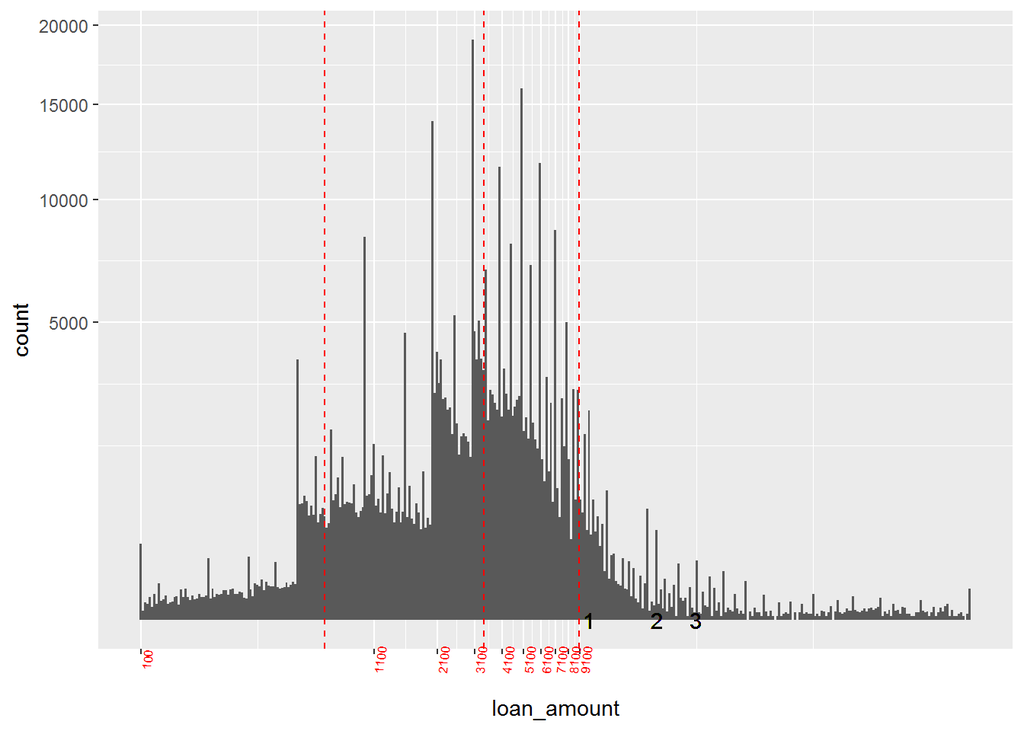

由摘要和绘图得：  
结论：借款人平均借款金额为4424元，中位数3397元。大部分人为小额借款，借款金额不大，95%的借款人借款金额在1万以下。借款金额最高达50万元。  
**2**

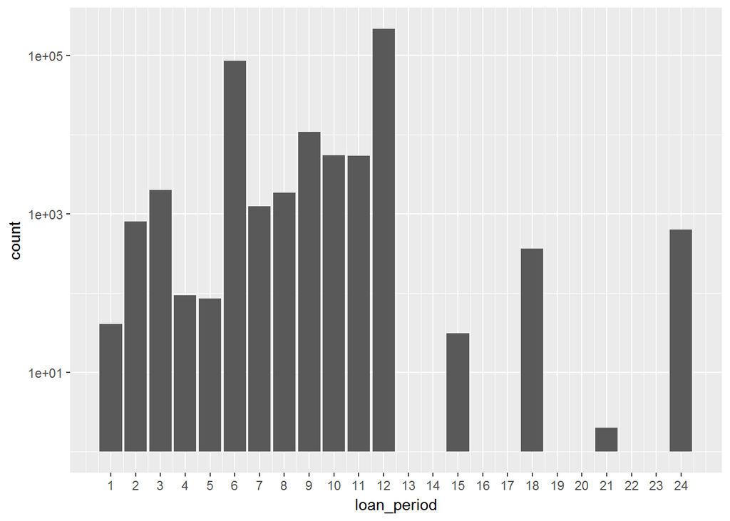

结论：借款期限最长为24个月，最短为1个月。其中大部分借款期限是6个月和12个月。借款期限在一年以内较多。

**3**

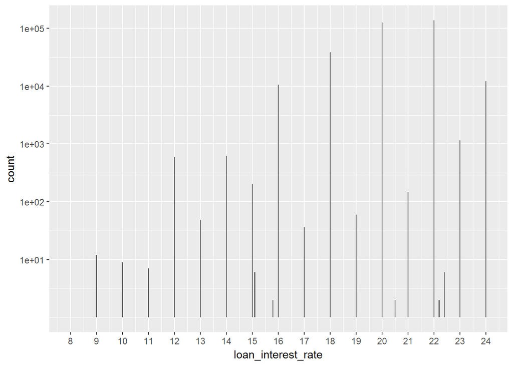

结论：借款利率多在年化率20%和22%，其次为18%。  
**4**

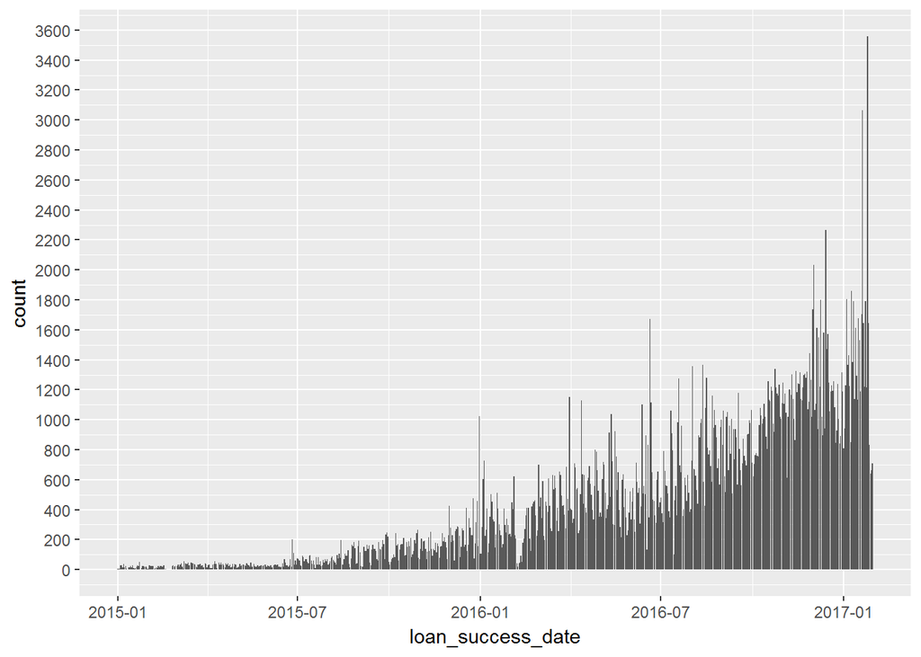

结论：借款成功量呈上升趋势，业务发展势头良好。  
**5**

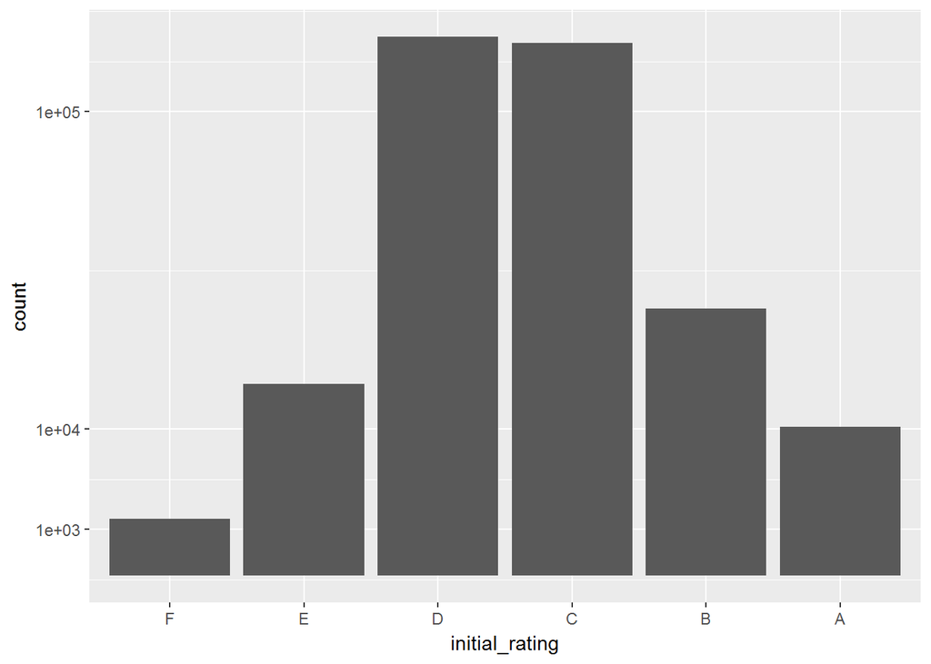

结论：初始评级从A到F，A为最高信用等级。被评为C和D级的借款人数量最多。

**6**

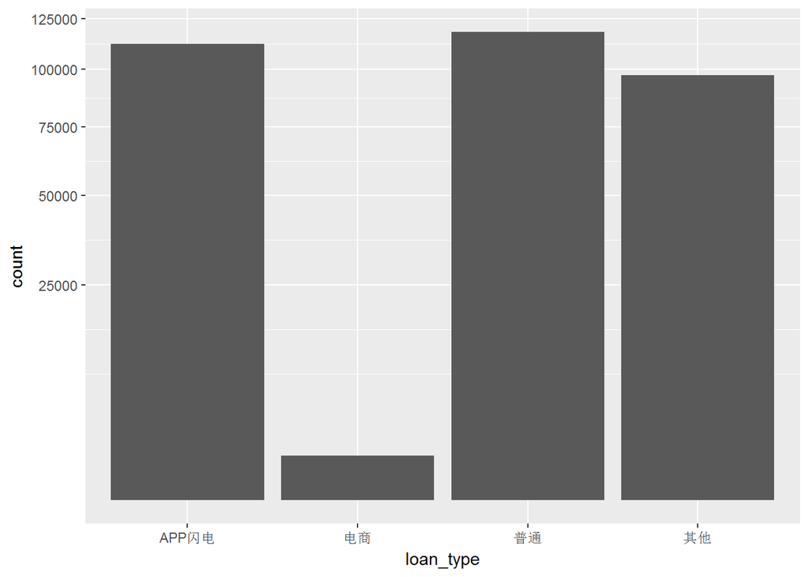

结论：共四种借款类型，选择电商这种借款类型的借款人数量较少。通过APP、普通、其他借款的数量相差不大。  
**7**

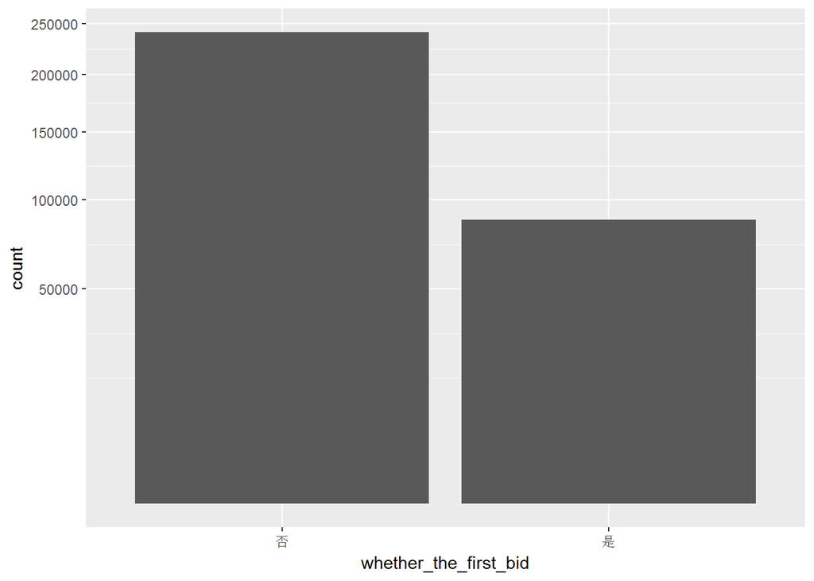

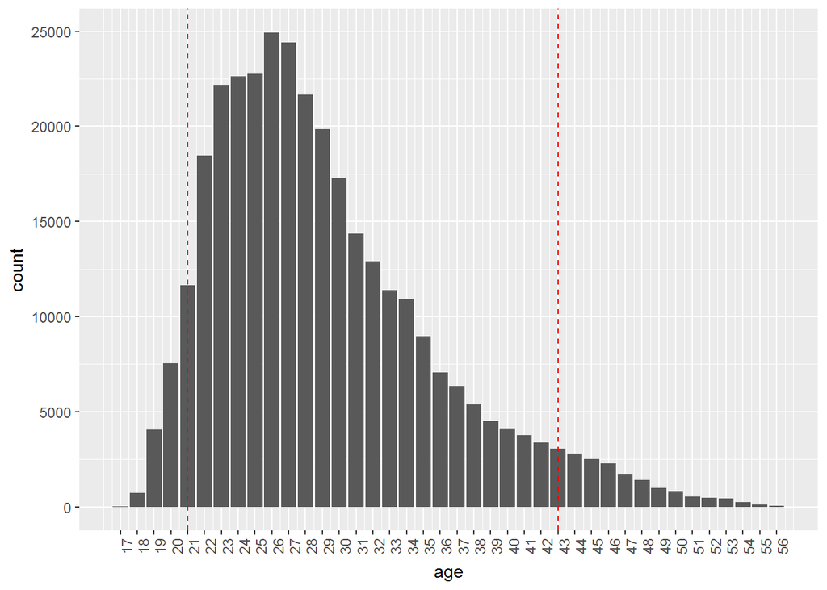

结论：借款用户的年龄在21-30岁的人数最多，中间90%的用户年龄在21-43岁。最小17岁。  
**9**

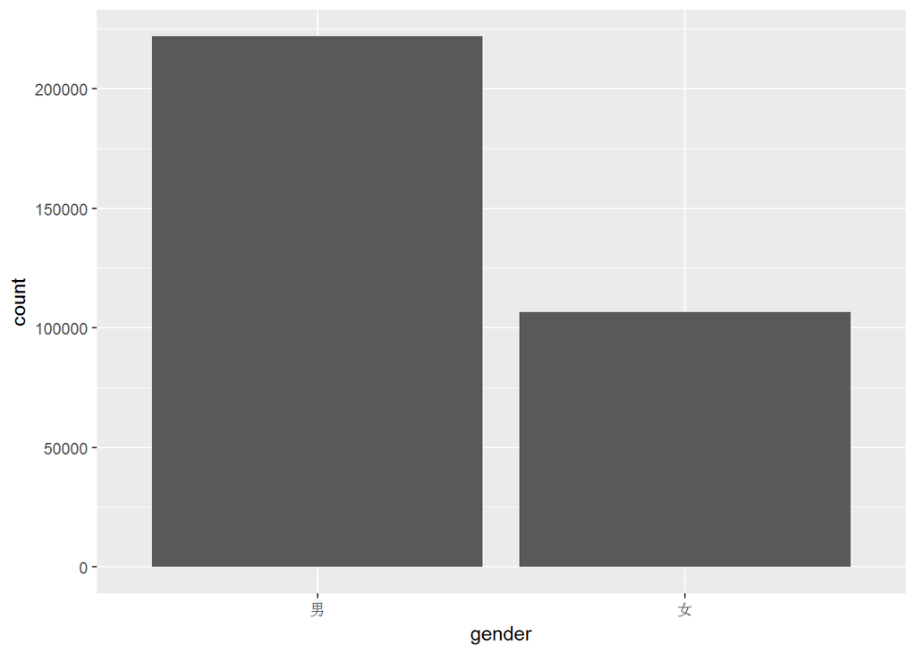

结论：借款用户中，男性是女性的约2倍。  
**10**

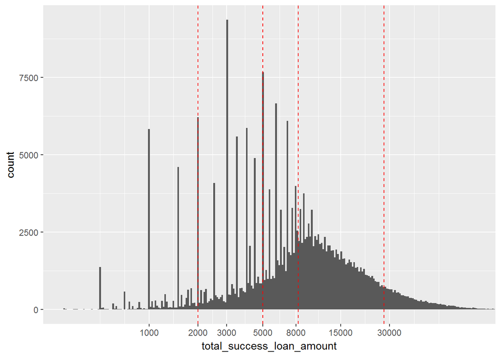

结论：历史成功借款金额95%在3万元以内，67%在8000元，50%在5000元，33%在2000元。  
**11**

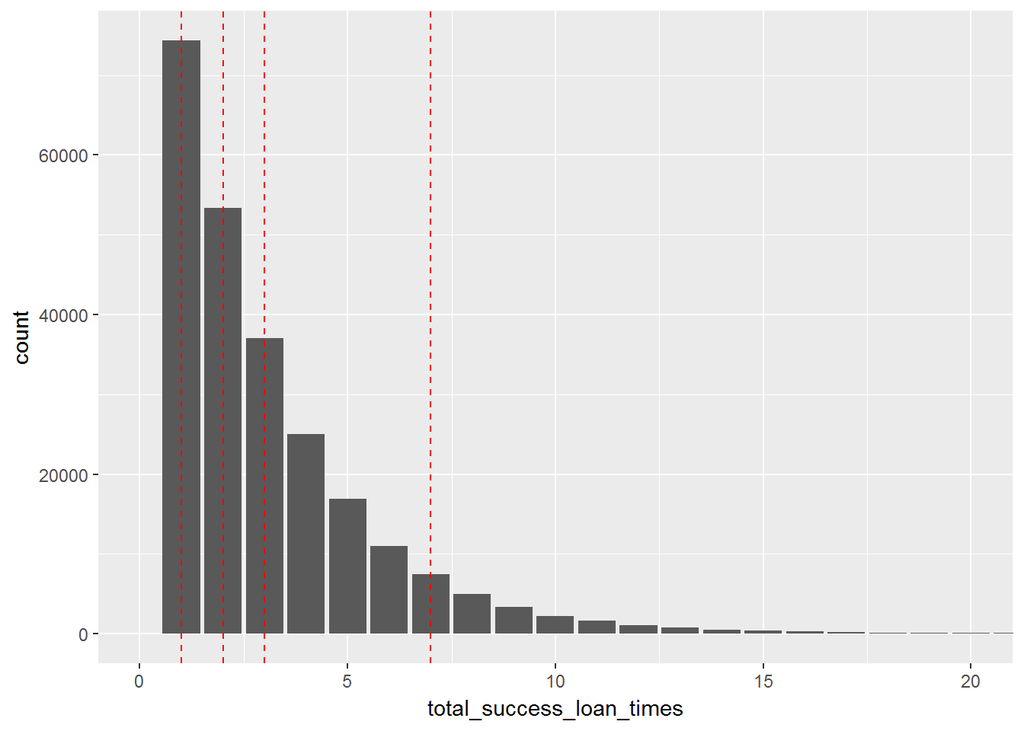

结论：历史成功借款次数中位数是2次，95%借款人借款次数在7次以内。  
**12**

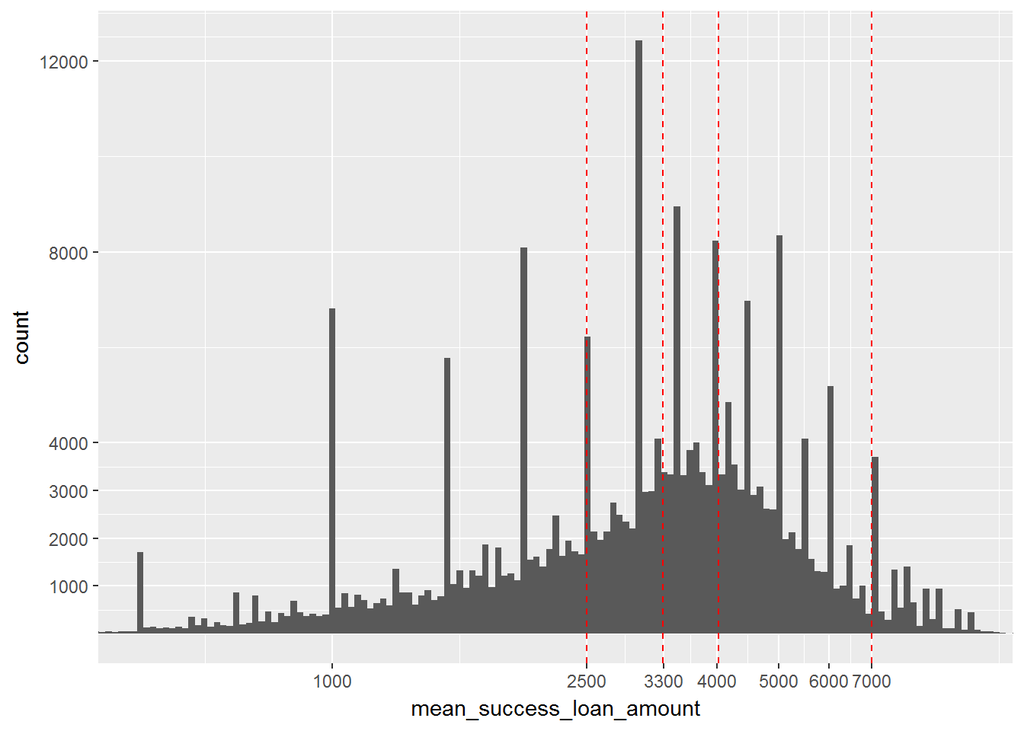

结论：历史平均成功借款金额集中在2500到5000元。中位数为3300元。95%的历史平均成功借款金额在7000元以内。  
**13**

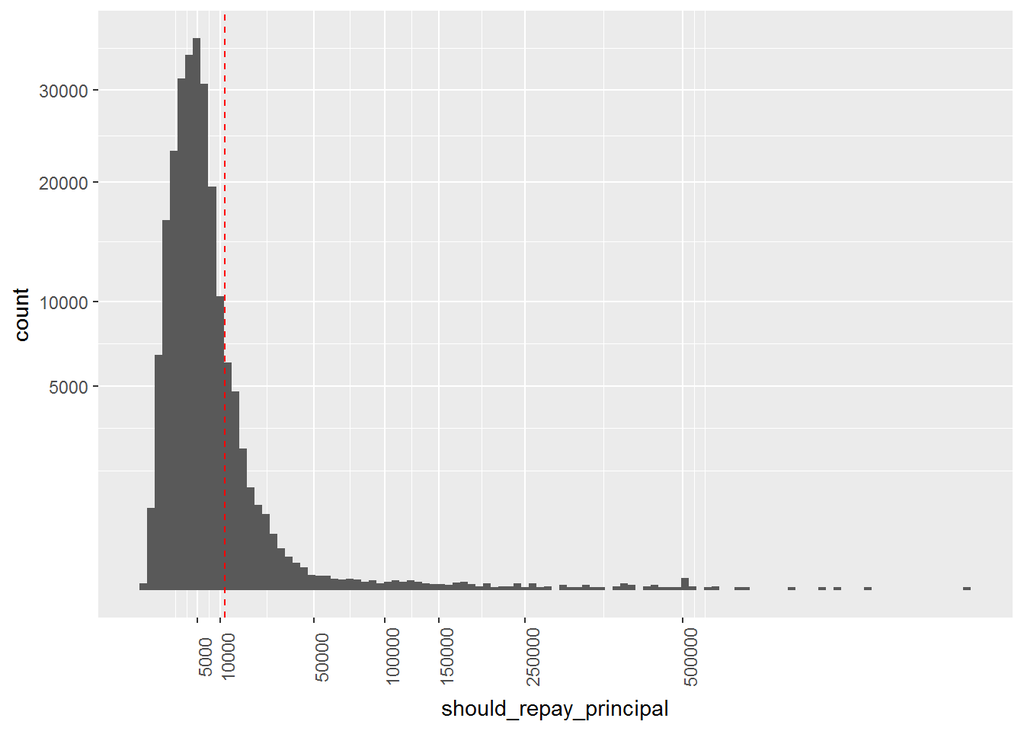

结论：95%的总待还本金在1万以内。总待还本金中位数2542元，最大值1172653元。  
**14**

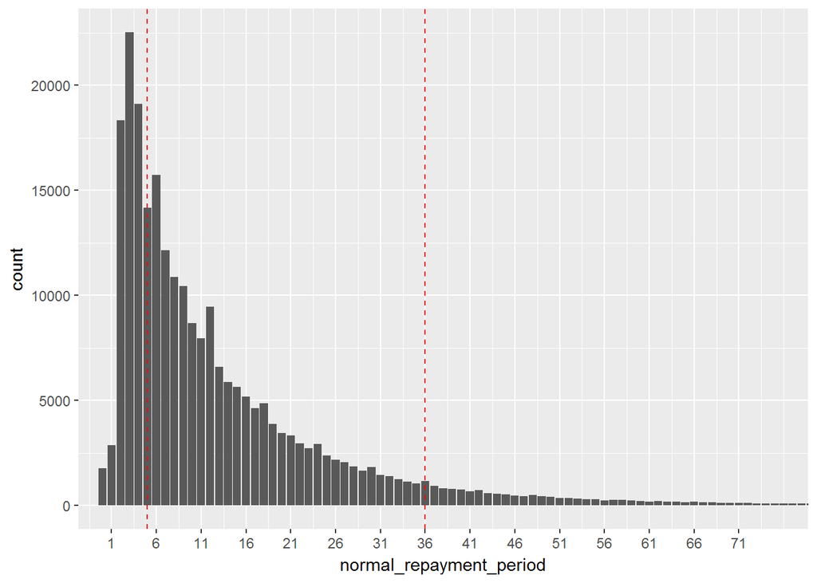

结论：历史成功借款金额大于零的数据中，历史正常还款期数的中位数是5期，95%的借款人历史正常还款期数在36期以内。

**15**

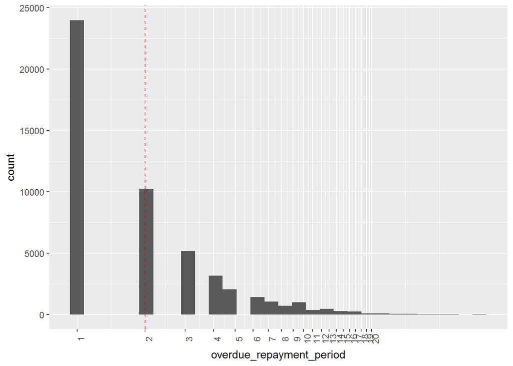

**16**

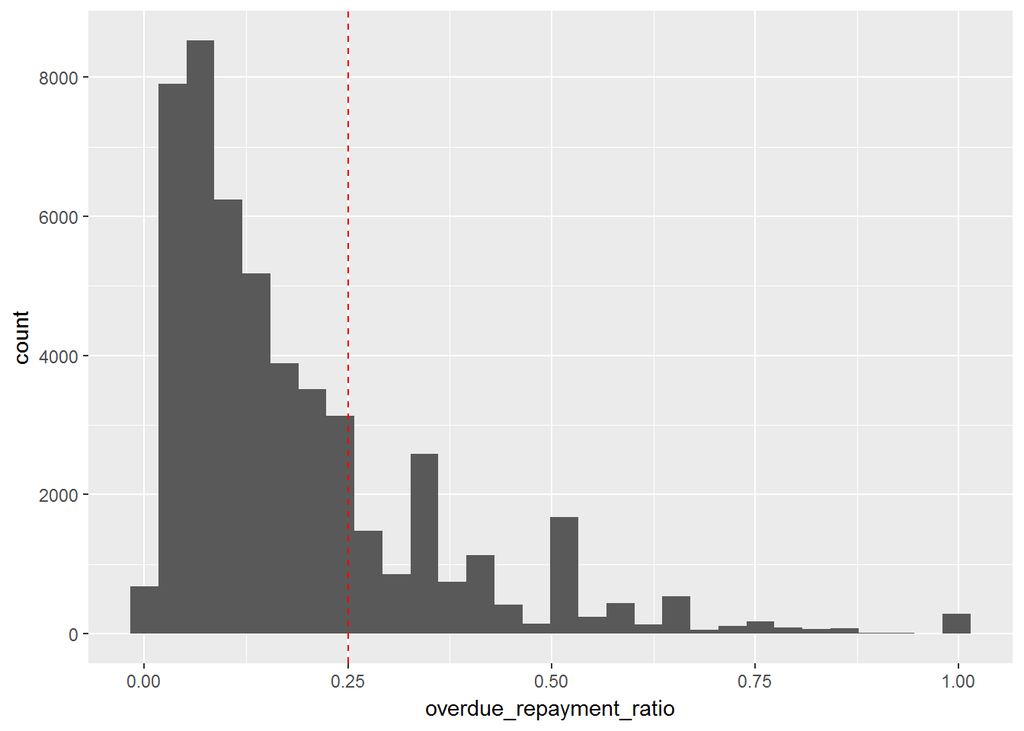

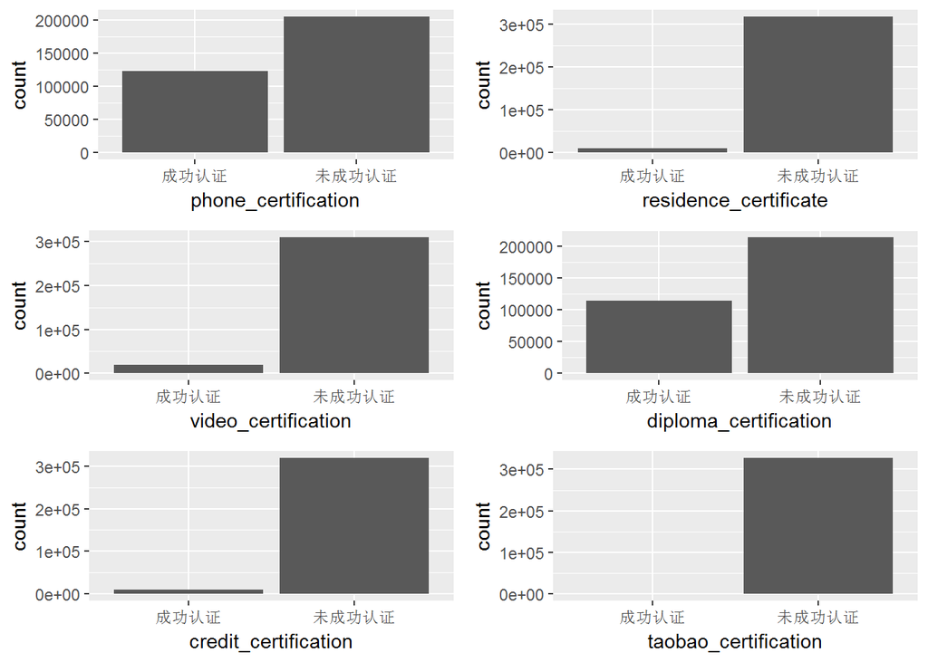

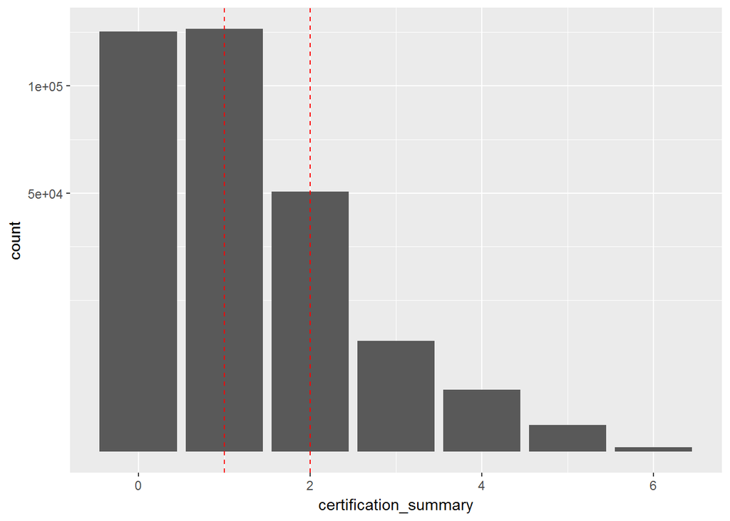

结论：共6种认证方式，手机认证、户口认、视频认证、学历认证、征信认、淘宝认证。其中手机认证、学历认证的成功认证人数最多，都超过了10万，其它认证成功的人数较少。没有认证和认证了1种方式的人数最多，达一半以上。95%以内的人最多认证了2种方式。

# ——单变量分析

### 你的数据集结构是什么？

lc数据框有328553个观测值，21个变量。

### 你的数据集内感兴趣的主要特性有哪些？

借款利率与哪些变量相关

### 你认为数据集内哪些其他特征可以帮助你探索兴趣特点？

借款金额、借款期限、借款成功日期（是否利率按年调整）、初始评级、是否首标、年龄、所有认证（认证种类及数量）、历史成功借款次数、历史成功借款金额、历史逾期还款期数

### 根据数据集内已有变量，你是否创建了任何新变量？

是。创建了新变量：借款成功年份、借款成功月份、借款成功日、所有认证（数量统计）、历史平均成功借款金额、历史逾期还款期数占比

### 在已经探究的特性中，是否存在任何异常分布？你是否对数据进行一些操作，如清洁、调整或改变数据的形式？如果是，你为什么会这样做？

在已经探究的特性中，存在异常的分布。  
有对数据进行数据类型的变化，删除认为是错误值的异常值所在行。  
在画图中，会根据情况，选择数据框的子集，也会使用sqrt和log让图形特点表达的更突出明确。

# ——双变量绘图选择

**1**

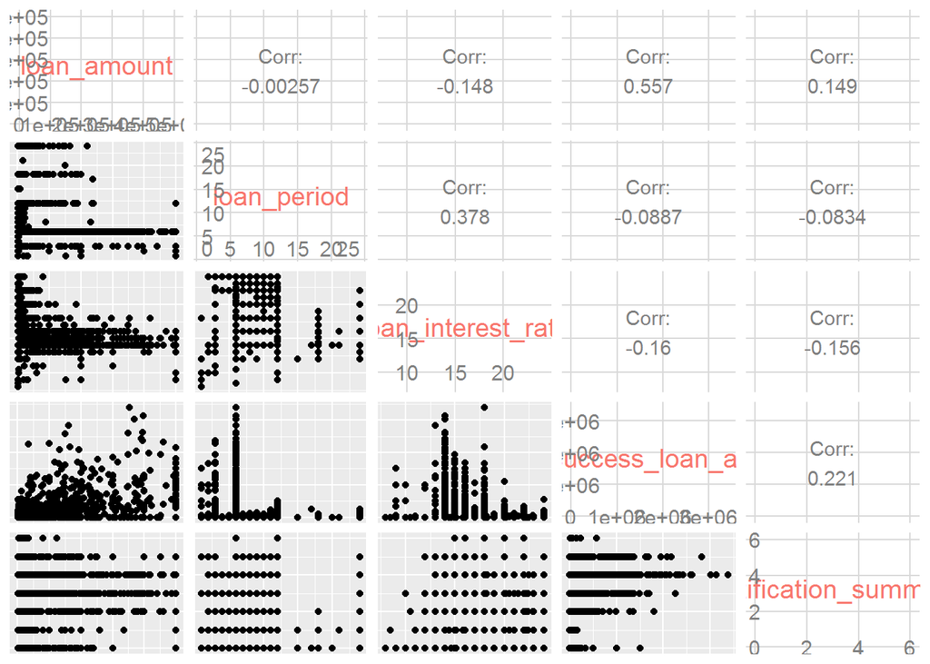

**2**

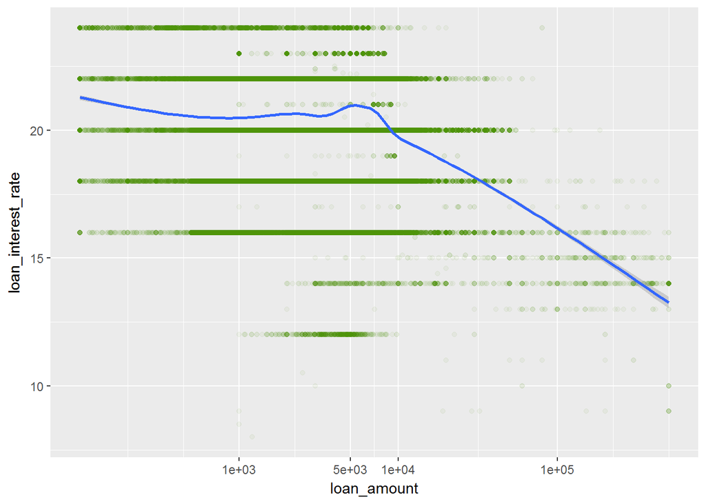

通过观察1图和上图：  
结论：借款金额和借款利率总体呈微弱负相关，相关系数-0.148。借款金额在5000以内时，借款利率几乎没有相关性，借款金额超过5000以后，借款金额越多，借款利率越低，借款利率随借款金额的增加呈快速降低趋势。  
**3**

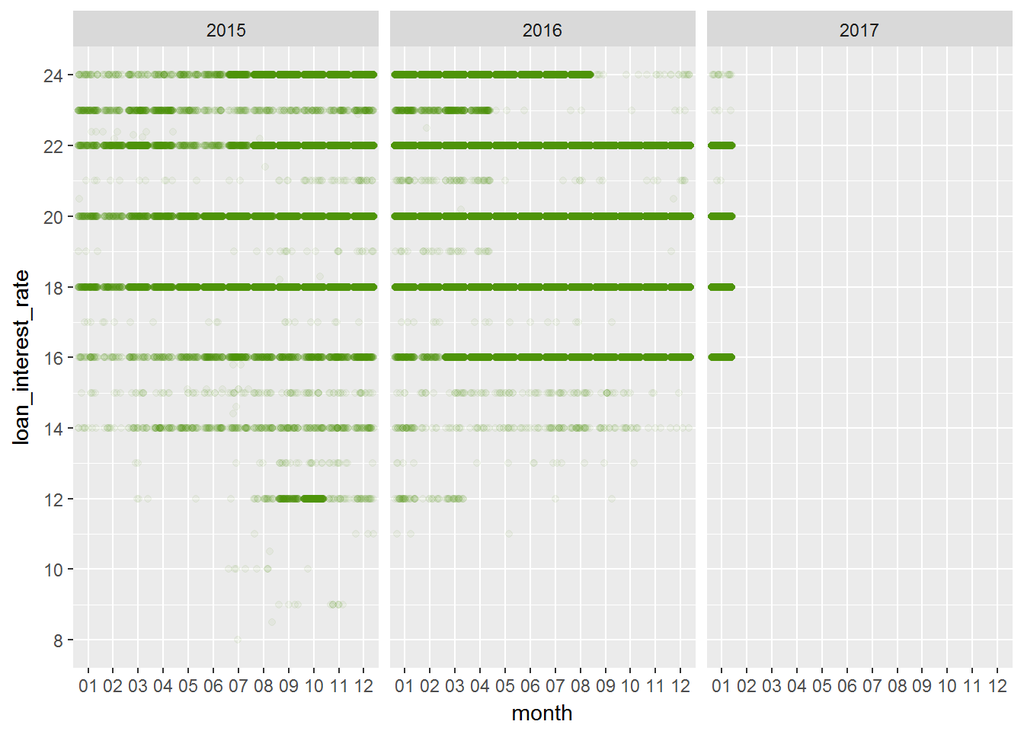

结论：借款利率与借款成功的时间在2015年至2016年7月期间观察几乎没有变化，但是从2016年8月起至2017年1月，借款利率在最高档24%成交的借款人明显变少。  
**4**

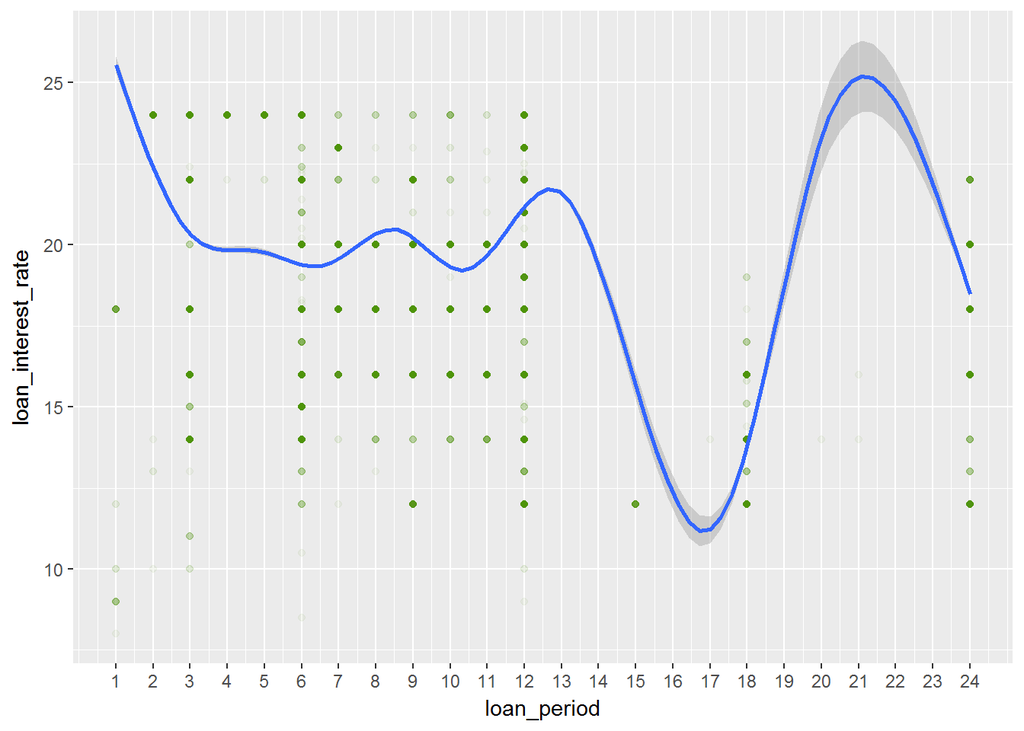

结论：虽然借款利率与借款期限总体相关系数0.378，观察上图，借款利率与借款期限并没有稳定的线性相关性。  
**5**

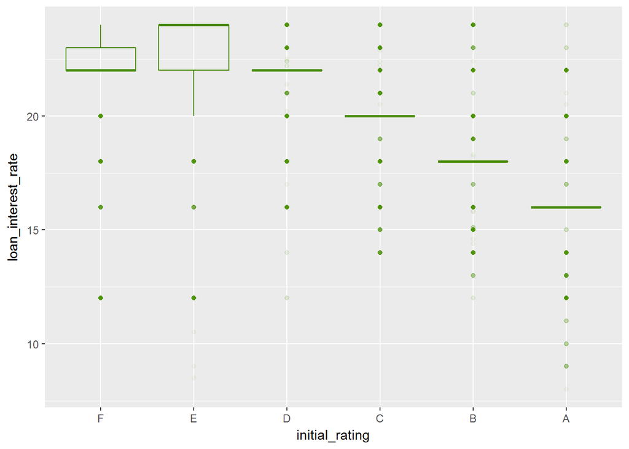

结论：大部分的情况下，初始评级越低，借款利率越高。  
**6**

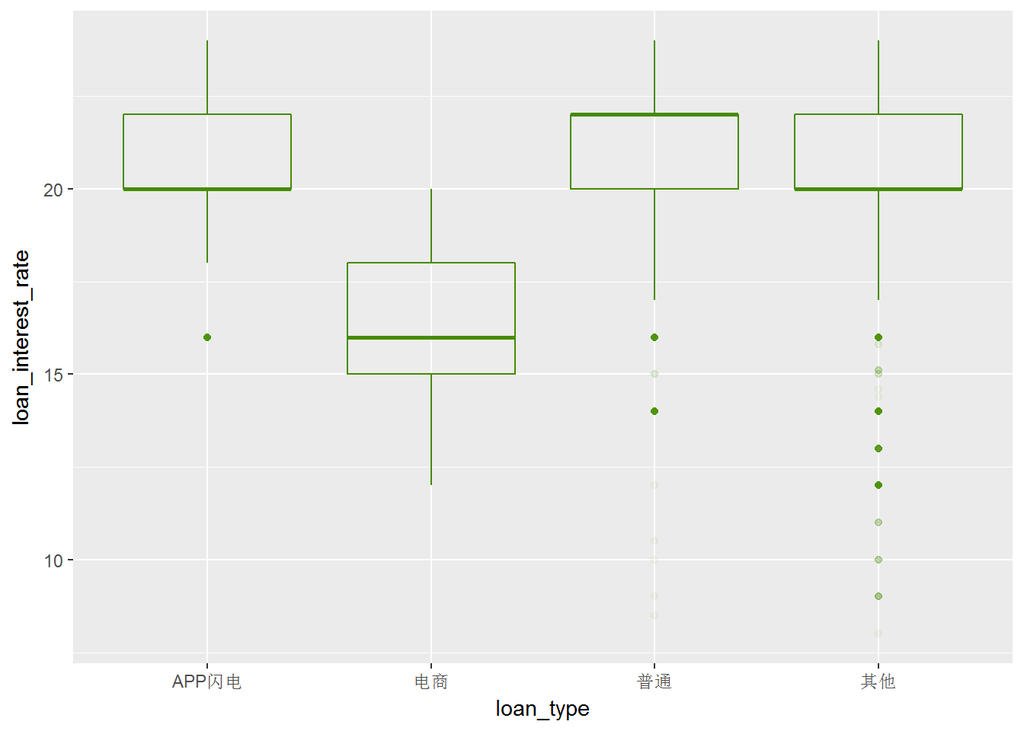

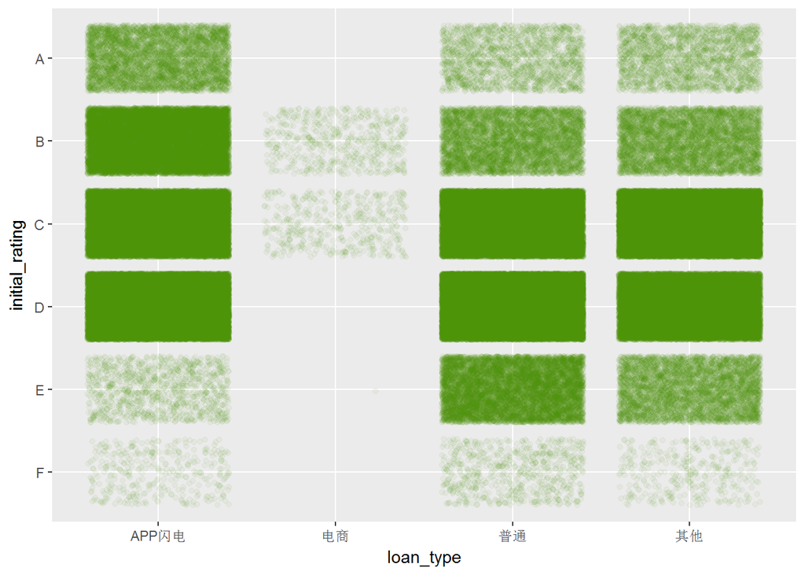

结论：电商借款类型的借款利率最低。电商借款类型的初始评级集中在B和C，由于初始评级和借款利率的关系为比较强的负相关，初始评级比较高，借款利率会比较低，推断此为电商借款类型的借款利率最低的原因。  
**7**

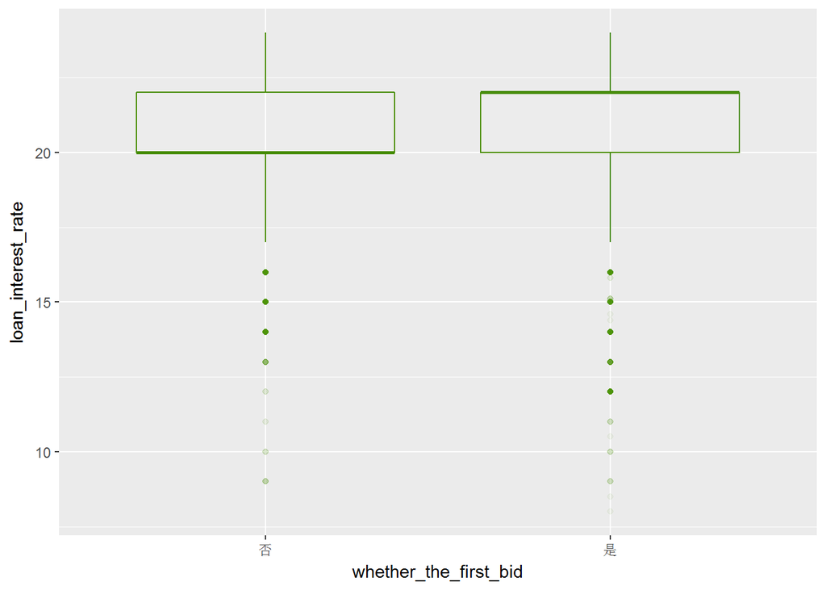

结论：首标的借款利率中位数要高于非首标的借款利率中位数约2%。认为是非首标借款用户对于投资用户来说，信任度更高，给的借款利率会低一些。  
**8**

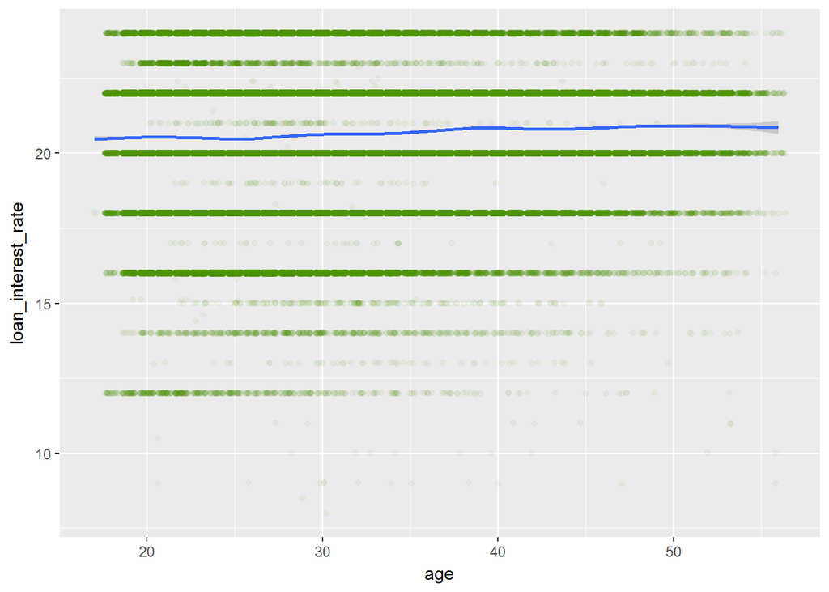

结论：借款利率与年龄没有相关性  
**9**

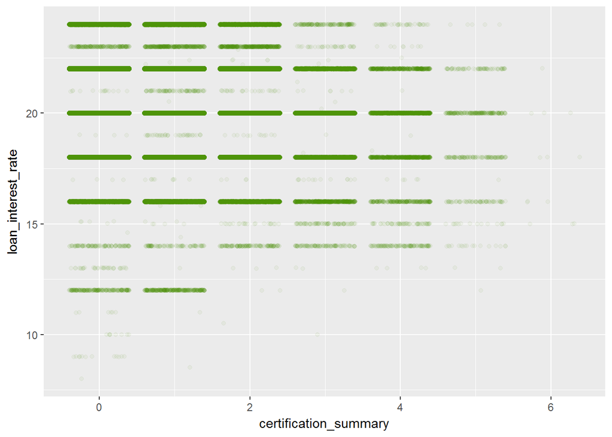